# CALIDAD DEL AGUA DEL RIO RIMAC

EQUIPO 3

31/3/2021

**UNIVERSIDAD NACIONAL AGRARIA LA MOLINA**

**PROFESOR: JESUS SALINAS**

**FACULTAD EYP**

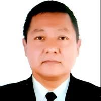

[figure not shown]

**INTEGRANTES**

LUIS EDGAR GUTIERREZ SALDANA

CHRISTIAN CRUZATE

JENNY MONTOYA

[figure not shown]

# 2.OBJETIVOS

El objetivo principal de este estudio es determinar patrones de variación temporal de la calidad de agua en el sector de la bocatoma de La Atarjea, Río Rímac. Los objetivos específicos son:

1. Identificar patrones temporales de variación de la calidad de agua.
2. Examinar la variación temporal de cada uno de los parámetros de la calidad de agua.
3. Identificar los parámetros de calidad de agua más importantes o relevantes.
4. Identificar relaciones entre parámetros de calidad de agua.

# 3.APLICANDO CLUSTER JERARQUICO

*AGRUPAMIENTO DE MESES(INDIVIDUOS)*

```r
library(readxl)
datosc <- read_excel("data_media.xlsx")
```

Estructura: Tenemos 24 variables de formato numerico y 1 variable en formato character(meses)

```r
str(datosc)
```

```
## tibble [12 x 25] (S3: tbl_df/tbl/data.frame)
##  $ meses: chr [1:12] "Ene" "Feb" "Mar" "Abr" ...
##  $ Caud : num [1:12] 40.6 56 71.9 47.6 26.3 23.1 23.5 21.7 22.8 22.4 ...
##  $ Temp : num [1:12] 19.2 20.2 20.2 20.1 18.5 17.2 16.6 15.7 16.5 18.6 ...
##  $ pH   : num [1:12] 7.7 7.8 7 7 8 7 7.8 7 7 8 ...
##  $ Turb : num [1:12] 47.2 301.9 391.7 100.4 12.5 ...
##  $ CE   : num [1:12] 488 440 402 426 595 ...
##  $ OD   : num [1:12] 8.7 8.84 8.94 8.51 8.55 8.64 9 8.76 8.7 8.64 ...
##  $ SD   : num [1:12] 338 308 278 284 380 ...
##  $ Akal : num [1:12] 95.6 91 81.6 91.3 120.4 ...
##  $ DI   : num [1:12] 211 189 165 176 255 ...
##  $ Cls  : num [1:12] 14.3 12.8 12.8 11.9 21.8 24.8 18.8 19.3 19.9 17.8 ...
##  $ so   : num [1:12] 138.6 116.5 97.5 114.6 146.7 ...
##  $ N03  : num [1:12] 2.98 2.78 2.54 2.41 3.38 3.64 3.83 3.58 3.61 3.38 ...
##  $ N02  : num [1:12] 0.2 0.13 0.08 0.1 0.21 0.3 0.23 0.28 0.18 0.24 ...
##  $ PO   : num [1:12] 0.2 0.14 0.09 0.18 0.23 0.28 0.32 0.38 0.36 0.34 ...
##  $ Cu   : num [1:12] 0.04 0.065 0.077 0.038 0.03 0.027 0.022 0.025 0.028 0.023 ...
##  $ Al   : num [1:12] 1.707 7.207 10.89 3.644 0.408 ...
##  $ Fe   : num [1:12] 2.176 7.595 11.37 4.471 0.434 ...
##  $ Mu   : num [1:12] 0.118 0.324 0.342 0.173 0.111 0.089 0.074 0.064 0.049 0.045 ...
##  $ Pb   : num [1:12] 0.024 0.081 0.079 0.056 0.015 0.02 0.013 0.015 0.022 0.012 ...
##  $ Cd   : num [1:12] 0.002 0.005 0.003 0.002 0.003 0.002 0.002 0.002 0.002 0.001 ...
##  $ Zn   : num [1:12] 0.372 0.611 0.641 0.343 0.468 0.323 0.273 0.28 0.28 0.171 ...
##  $ As   : num [1:12] 0.029 0.126 0.088 0.074 0.024 0.023 0.022 0.019 0.022 0.022 ...
##  $ Colo : num [1:12] 178600 247014 208035 174967 160299 ...
##  $ Cole : num [1:12] 74326 95332 90325 58096 63802 ...
```

Convirtiendo en un dataframe:

```r
datosc=as.data.frame(datosc)
```

```r
rownames(datosc)<- datosc$meses
```

Eliminanos la variable meses(cualitativa)

```r
datosc$meses=NULL
head(datosc,3)
```

|  | Caud | Temp | pH | Turb | CE | OD | SD | Akal | DI | Cls | so | N03 | N02 | PO | Cu | Al | Fe | Mu | Pb | Cd | Zn | As | Colo | Cole |
| --- | --- | --- | --- | --- | --- | --- | --- | --- | --- | --- | --- | --- | --- | --- | --- | --- | --- | --- | --- | --- | --- | --- | --- | --- |
| Ene | 40.6 | 19.2 | 7.7 | 47.2 | 487.71 | 8.70 | 337.86 | 95.6 | 211.4 | 14.3 | 138.6 | 2.98 | 0.20 | 0.20 | 0.040 | 1.707 | 2.176 | 0.118 | 0.024 | 0.002 | 0.372 | 0.029 | 178600 | 74326 |
| Feb | 56.0 | 20.2 | 7.8 | 301.9 | 440.00 | 8.84 | 307.96 | 91.0 | 189.1 | 12.8 | 116.5 | 2.78 | 0.13 | 0.14 | 0.065 | 7.207 | 7.595 | 0.324 | 0.081 | 0.005 | 0.611 | 0.126 | 247014 | 95332 |
| Mar | 71.9 | 20.2 | 7.0 | 391.7 | 401.96 | 8.94 | 278.04 | 81.6 | 164.6 | 12.8 | 97.5 | 2.54 | 0.08 | 0.09 | 0.077 | 10.890 | 11.370 | 0.342 | 0.079 | 0.003 | 0.641 | 0.088 | 208035 | 90325 |

**ANALISIS EXPLORATORIO**

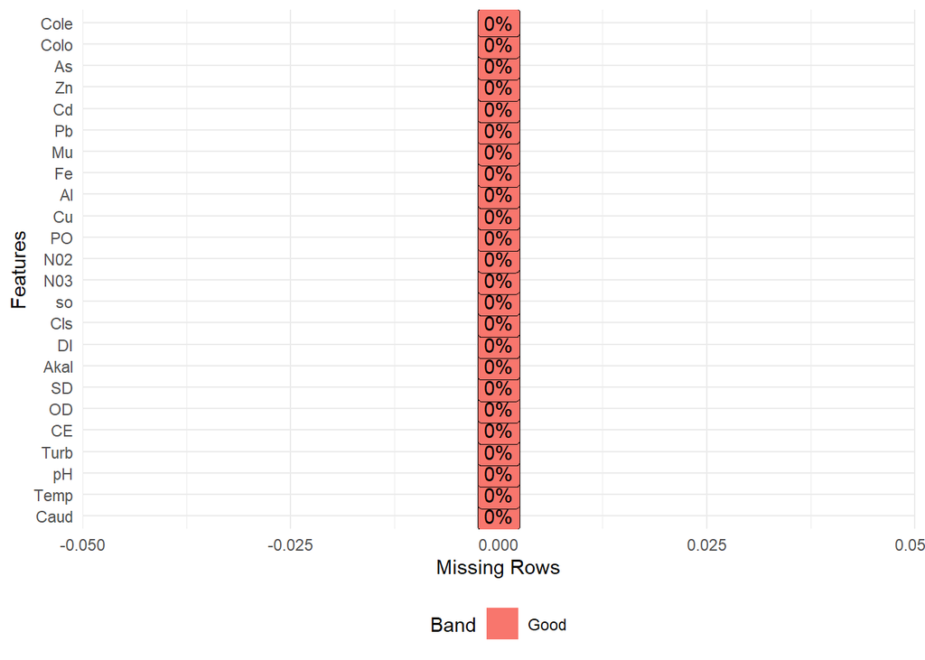

```r
#Verificando si hay valores faltantes:
#Detectando y graficando los % de datos perdidos
#No hay valores perdidos en ninguna variable
library(DataExplorer)
library(ggplot2)
plot_missing(datosc,ggtheme=theme_minimal())
```

**ANALISIS DESCRIPTIVO**

```r
library(zoo)
library(PerformanceAnalytics)
```

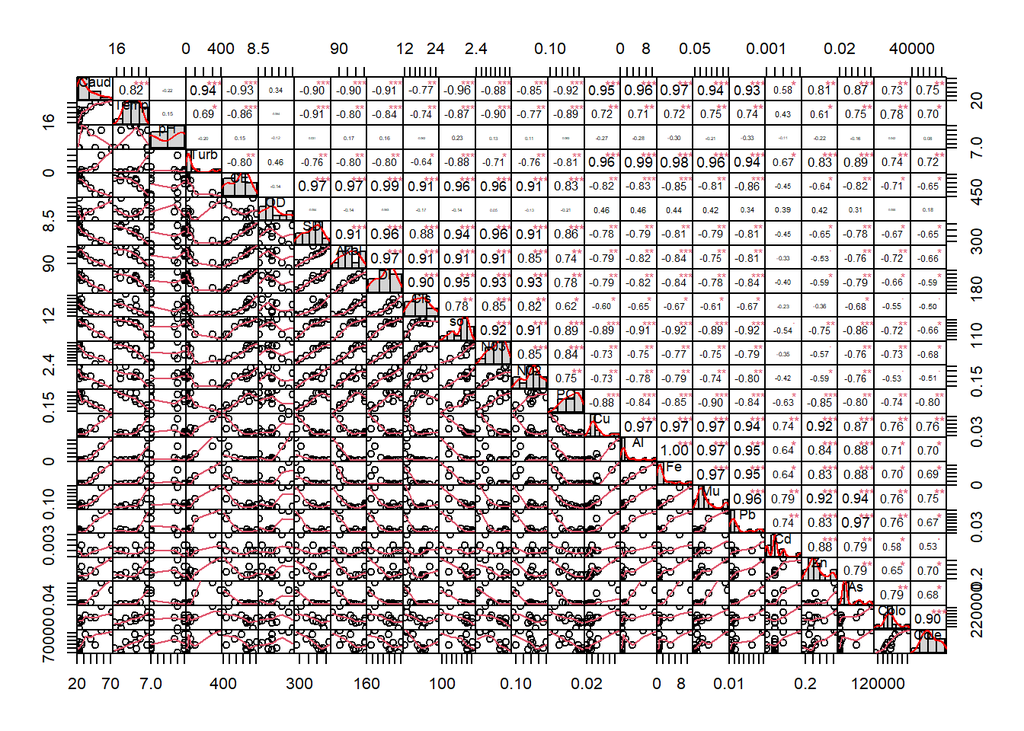

```r
library(xts)
library(graphics)
#pearson "escala de intervalo"#es mejor si el tamaño de muestra es mas grande.
chart.Correlation(datosc, histogram=TRUE, method = c("pearson"), pch=20)
```

Se observa que 22 variables sus coeficientes correlacion de pearson es alto, es decir las variables se encuentran altamente correlacionados excepto las variables (PH) y oxigeno disuelto(OD) son las que tienen una menor correlacion de pearson, es decir estas ultimas variables se encuentran poco correlacionados con las demas variables.